# EST077 (2023/1) - Exercicio Computacional II

Gabriela Paschoal 201965038AD

2023-04-23

### Teorema do Limite Central de Forma Empirica (Parte II - Distribuições Não-Normais)

#### Obs: Para este exercicio, utilizei a semente 666 e a biblioteca simcausal (para gerar a distribuicao bernoulli).

#### O primeiro passo consistiu na criacao de matrizes de ordem 1000 x n para armazenar as amostras dos tamanhos n requeridos.

### Uniforme (1,5)

```r
# Considere que tem uma população com uma distribuição conhecida (descrita
# abaixo). Gere 1000 amostras de tamanho n (n=20, 50, 100, 200 e 500)
# provenientes desta população.

amostras20<-matrix(data = NA, nrow = 1000, ncol = 20 )
# cada linha armazena uma amostra de tam 20

i<-1

while (i <= 1000){

      amostras20[i,]<-runif(20, min = 1, max = 5)
      i<- i+1

}

any(is.na(amostras20)) # verifica se matriz contem NA's
```

```
## [1] FALSE
```

```r
# ------------------------------------------------------------------------------

amostras50<-matrix(data = NA, nrow = 1000, ncol = 50 )
# cada linha armazena uma amostra de tam 20

i<-1

while (i <= 1000){

      amostras50[i,]<-runif(50, min = 1, max = 5)
      i<- i+1

}

any(is.na(amostras50)) # verifica se matriz contem NA's
```

```
## [1] FALSE
```

```r
# ------------------------------------------------------------------------------

amostras100<-matrix(data = NA, nrow = 1000, ncol = 100 )
# cada linha armazena uma amostra de tam 20

i<-1

while (i <= 1000){

      amostras100[i,]<-runif(100, min = 1, max = 5)
      i<- i+1

}

any(is.na(amostras100)) # verifica se matriz contem NA's
```

```
## [1] FALSE
```

```r
# ------------------------------------------------------------------------------

amostras200<-matrix(data = NA, nrow = 1000, ncol = 200 )
# cada linha armazena uma amostra de tam 20

i<-1

while (i <= 1000){

      amostras200[i,]<-runif(200, min = 1, max = 5)
      i<- i+1

}

any(is.na(amostras200)) # verifica se matriz contem NA's
```

```
## [1] FALSE
```

```r
# ------------------------------------------------------------------------------

amostras500<-matrix(data = NA, nrow = 1000, ncol = 500 )
# cada linha armazena uma amostra de tam 20

i<-1

while (i <= 1000){

      amostras500[i,]<-runif(500, min = 1, max = 5)
      i<- i+1

}

any(is.na(amostras500)) # verifica se matriz contem NA's
```

```
## [1] FALSE
```

#### Em seguida, foram criados vetores para as medias amostrais.

```r
# Para cada amostra gerada calcule a média amostral e com esses 1000 valores, estude a distribuição da estatística Média Amostral (de forma empírica, pois teoricamente já fizemos isso). Faça histograma e descreva o que observa.   A distribuição da estatística média amostral está centrada em qual valor? E sobre a variabilidade, o que pode dizer?
# Esta distribuição é simétrica ou assimétrica? A partir de que valor de n, vc
# observa que esta aproximação é "boa"?

medias20<-numeric(1000)
# vetor para armazenar 1000 medias

i<-1

while (i <= 1000){

      medias20[i]<-mean(amostras20[i,])
      i<-i+1

}

#-------------------------------------------------------------------------------

medias50<-numeric(1000)
i<-1

while (i <= 1000){

      medias50[i]<-mean(amostras50[i,])
      i<-i+1

}

#-------------------------------------------------------------------------------

medias100<-numeric(1000)
i<-1

while (i <= 1000){

      medias100[i]<-mean(amostras100[i,])
      i<-i+1

}

#-------------------------------------------------------------------------------

medias200<-numeric(1000)
i<-1

while (i <= 1000){

      medias200[i]<-mean(amostras200[i,])
      i<-i+1

}

#-------------------------------------------------------------------------------

medias500<-numeric(1000)
i<-1

while (i <= 1000){

      medias500[i]<-mean(amostras500[i,])
      i<-i+1

}
```

#### Por fim, foi feita a plotagem dos histogramas.

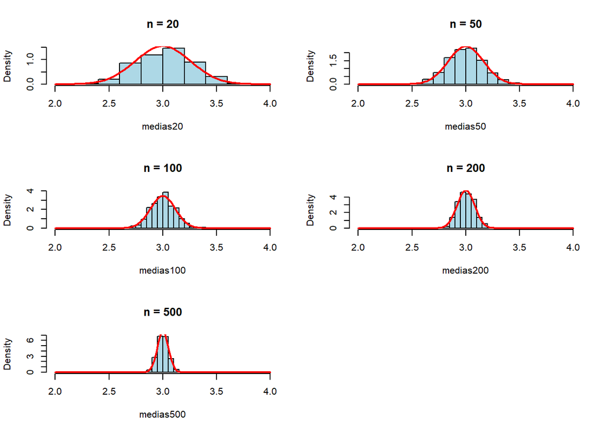

```r
# GRAFICOS ---------------------------------------------------------------------

par(mfrow = c(3,2), mar = c(5, 4, 4, 2) + 0.1)

hist(medias20, freq = FALSE, col = 'lightblue', main = 'n = 20', xlim = c(2,4))
curve(dnorm(x, mean=3, sd=sqrt((16/12)/20)), col = 'red', add = TRUE, lwd = 2)

hist(medias50, freq = FALSE, col = 'lightblue', main = 'n = 50', xlim = c(2,4))
curve(dnorm(x, mean=3, sd=sqrt((16/12)/50)), col = 'red', add = TRUE, lwd = 2)

hist(medias100, freq = FALSE, col = 'lightblue', main = 'n = 100', xlim = c(2,4))
curve(dnorm(x, mean=3, sd=sqrt((16/12)/100)), col = 'red', add = TRUE, lwd = 2)

hist(medias200, freq = FALSE, col = 'lightblue', main = 'n = 200', xlim = c(2,4))
curve(dnorm(x, mean=3, sd=sqrt((16/12)/200)), col = 'red', add = TRUE, lwd = 2)

hist(medias500, freq = FALSE, col = 'lightblue', main = 'n = 500', xlim = c(2,4))
curve(dnorm(x, mean=3, sd=sqrt((16/12)/500)), col = 'red', add = TRUE, lwd = 2)
```

#### Pelo teorema central do limite, sabemos que para qualquer populacao com media e variancia, a distribuicao das medias amostrais segue - para n suficientemente grande - uma normal com media equivalente a populacional e variancia igual a variancia populacional sobre o tamannho amostral n. Para a uniforme, percebe-se que os valores ficam centrados em torno da media logo em n = 20, revelando que o tamanho ‘suficientemente grande’ de n vai ser um valor mais baixo, provavelmente devido ao carater simetrico da distribuicao uniforme. A aproximacao da distribuicao pela normal parece ficar razoavel para n = 20, boa para n = 50 e muito boa para n >100. Quanto a variabilidade, essa reduz conforme n aumenta (e conforme era esperado pelo tcl).

#### Os mesmos procedimentos acima foram repetidos para outras distribuicoes estatisticas: expo(1), expo(3), t-student(3), bernoulli(0,1), bernoulli(0,3), bernoulli(0,5), bernoulli(0,8), poisson(0,4).

### Exponencial(1)

```r
# Considere que tem uma população com uma distribuição conhecida (descrita
# abaixo). Gere 1000 amostras de tamanho n (n=20, 50, 100, 200 e 500)
# provenientes desta população.

amostras20<-matrix(data = NA, nrow = 1000, ncol = 20 )
# cada linha armazena uma amostra de tam 20

i<-1

while (i <= 1000){

      amostras20[i,]<-rexp(20, rate = 1)
      i<- i+1

}

any(is.na(amostras20)) # verifica se matriz contem NA's
```

```
## [1] FALSE
```

```r
# ------------------------------------------------------------------------------

amostras50<-matrix(data = NA, nrow = 1000, ncol = 50 )
# cada linha armazena uma amostra de tam 20

i<-1

while (i <= 1000){

      amostras50[i,]<-rexp(50, rate = 1)
      i<- i+1

}

any(is.na(amostras50)) # verifica se matriz contem NA's
```

```
## [1] FALSE
```

```r
# ------------------------------------------------------------------------------

amostras100<-matrix(data = NA, nrow = 1000, ncol = 100 )
# cada linha armazena uma amostra de tam 20

i<-1

while (i <= 1000){

      amostras100[i,]<-rexp(100, rate = 1)
      i<- i+1

}

any(is.na(amostras100)) # verifica se matriz contem NA's
```

```
## [1] FALSE
```

```r
# ------------------------------------------------------------------------------

amostras200<-matrix(data = NA, nrow = 1000, ncol = 200 )
# cada linha armazena uma amostra de tam 20

i<-1

while (i <= 1000){

      amostras200[i,]<-rexp(200, rate = 1)
      i<- i+1

}

any(is.na(amostras200)) # verifica se matriz contem NA's
```

```
## [1] FALSE
```

```r
# ------------------------------------------------------------------------------

amostras500<-matrix(data = NA, nrow = 1000, ncol = 500 )
# cada linha armazena uma amostra de tam 20

i<-1

while (i <= 1000){

      amostras500[i,]<-rexp(500, rate = 1)
      i<- i+1

}

any(is.na(amostras500)) # verifica se matriz contem NA's
```

```
## [1] FALSE
```

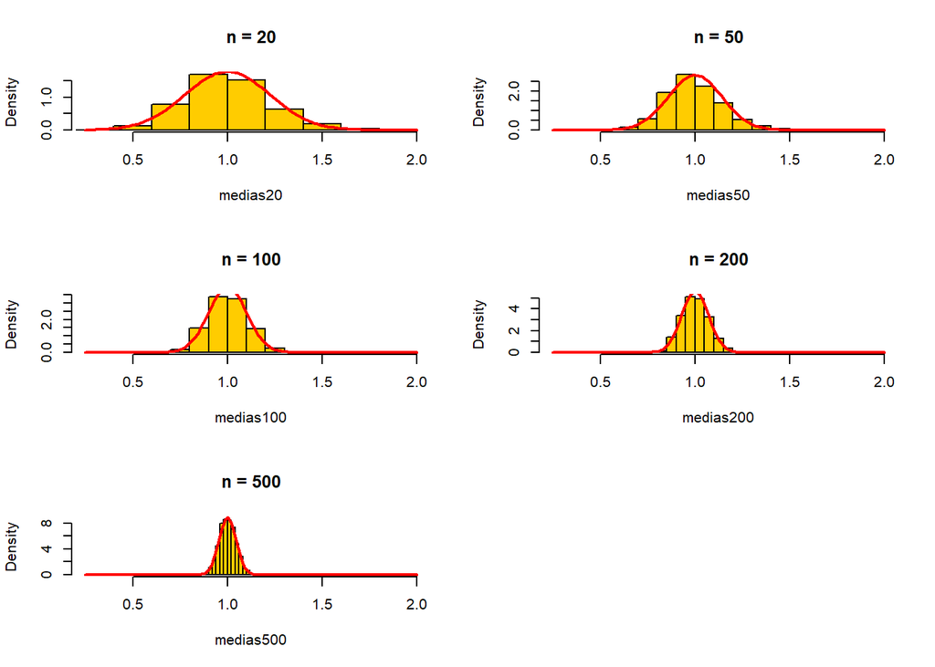

```r
# Para cada amostra gerada calcule a média amostral.

medias20<-numeric(1000)
# vetor para armazenar 1000 medias

i<-1

while (i <= 1000){

      medias20[i]<-mean(amostras20[i,])
      i<-i+1

}

#-------------------------------------------------------------------------------

medias50<-numeric(1000)
i<-1

while (i <= 1000){

      medias50[i]<-mean(amostras50[i,])
      i<-i+1

}

#-------------------------------------------------------------------------------

medias100<-numeric(1000)
i<-1

while (i <= 1000){

      medias100[i]<-mean(amostras100[i,])
      i<-i+1

}

#-------------------------------------------------------------------------------

medias200<-numeric(1000)
i<-1

while (i <= 1000){

      medias200[i]<-mean(amostras200[i,])
      i<-i+1

}

#-------------------------------------------------------------------------------

medias500<-numeric(1000)
i<-1

while (i <= 1000){

      medias500[i]<-mean(amostras500[i,])
      i<-i+1

}


# GRAFICOS ---------------------------------------------------------------------

par(mfrow = c(3,2), mar = c(5, 4, 4, 2) + 0.1)

hist(medias20, freq = FALSE, col = '#FFCC00', main = 'n = 20', xlim= c(0.25, 2))
curve(dnorm(x, mean=1, sd=sqrt(1/20)), col = 'red', add = TRUE, lwd = 2)

hist(medias50, freq = FALSE, col = '#FFCC00', main = 'n = 50', xlim= c(0.25, 2))
curve(dnorm(x, mean=1, sd=sqrt(1/50)), col = 'red', add = TRUE, , lwd = 2)

hist(medias100, freq = FALSE, col = '#FFCC00', main = 'n = 100',xlim= c(0.25, 2))
curve(dnorm(x, mean=1, sd=sqrt(1/100)), col = 'red', add = TRUE, lwd = 2)

hist(medias200, freq = FALSE, col = '#FFCC00', main = 'n = 200', xlim= c(0.25, 2))
curve(dnorm(x, mean=1, sd=sqrt(1/200)), col = 'red', add = TRUE,lwd = 2)

hist(medias500, freq = FALSE, col = '#FFCC00', main = 'n = 500',xlim= c(0.25, 2))
curve(dnorm(x, mean=1, sd=sqrt(1/500)), col = 'red', add = TRUE, lwd = 2)
```

#### Valor de n suficientemente grande parece ser algo entre 20 e 50, mas foi somente em n = 200 que o histograma se mostrou com simetria muito boa. A media logo de inicio estava centrada na media populacional, e a variancia reduz a medida de que n cresce (esperado pelo tcl).

### Exponencial(3)

```r
# Considere que tem uma população com uma distribuição conhecida (descrita
# abaixo). Gere 1000 amostras de tamanho n (n=20, 50, 100, 200 e 500)
# provenientes desta população.

amostras20<-matrix(data = NA, nrow = 1000, ncol = 20 )
# cada linha armazena uma amostra de tam 20

i<-1

while (i <= 1000){

      amostras20[i,]<-rexp(20, rate = 3)
      i<- i+1

}

any(is.na(amostras20)) # verifica se matriz contem NA's
```

```
## [1] FALSE
```

```r
# ------------------------------------------------------------------------------

amostras50<-matrix(data = NA, nrow = 1000, ncol = 50 )
# cada linha armazena uma amostra de tam 20

i<-1

while (i <= 1000){

      amostras50[i,]<-rexp(50, rate = 3)
      i<- i+1

}

any(is.na(amostras50)) # verifica se matriz contem NA's
```

```
## [1] FALSE
```

```r
# ------------------------------------------------------------------------------

amostras100<-matrix(data = NA, nrow = 1000, ncol = 100 )
# cada linha armazena uma amostra de tam 20

i<-1

while (i <= 1000){

      amostras100[i,]<-rexp(100, rate = 3)
      i<- i+1

}

any(is.na(amostras100)) # verifica se matriz contem NA's
```

```
## [1] FALSE
```

```r
# ------------------------------------------------------------------------------

amostras200<-matrix(data = NA, nrow = 1000, ncol = 200 )
# cada linha armazena uma amostra de tam 20

i<-1

while (i <= 1000){

      amostras200[i,]<-rexp(200, rate = 3)
      i<- i+1

}

any(is.na(amostras200)) # verifica se matriz contem NA's
```

```
## [1] FALSE
```

```r
# ------------------------------------------------------------------------------

amostras500<-matrix(data = NA, nrow = 1000, ncol = 500 )
# cada linha armazena uma amostra de tam 20

i<-1

while (i <= 1000){

      amostras500[i,]<-rexp(500, rate = 3)
      i<- i+1

}

any(is.na(amostras500)) # verifica se matriz contem NA's
```

```
## [1] FALSE
```

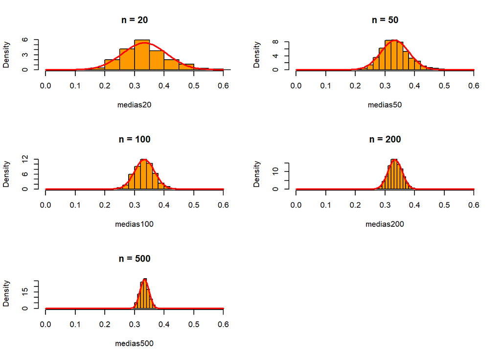

```r
# Para cada amostra gerada calcule a média amostral.

medias20<-numeric(1000)
# vetor para armazenar 1000 medias

i<-1

while (i <= 1000){

      medias20[i]<-mean(amostras20[i,])
      i<-i+1

}

#-------------------------------------------------------------------------------

medias50<-numeric(1000)
i<-1

while (i <= 1000){

      medias50[i]<-mean(amostras50[i,])
      i<-i+1

}

#-------------------------------------------------------------------------------

medias100<-numeric(1000)
i<-1

while (i <= 1000){

      medias100[i]<-mean(amostras100[i,])
      i<-i+1

}

#-------------------------------------------------------------------------------

medias200<-numeric(1000)
i<-1

while (i <= 1000){

      medias200[i]<-mean(amostras200[i,])
      i<-i+1

}

#-------------------------------------------------------------------------------

medias500<-numeric(1000)
i<-1

while (i <= 1000){

      medias500[i]<-mean(amostras500[i,])
      i<-i+1

}


# GRAFICOS ---------------------------------------------------------------------

par(mfrow = c(3,2), mar = c(5, 4, 4, 2) + 0.1)

hist(medias20, freq = FALSE, col = '#FF9900', main = 'n = 20', xlim= c(0, 0.6))
curve(dnorm(x, mean=1/3, sd=sqrt((1/3**2)/20)), col = 'red', add = TRUE, lwd = 2)

hist(medias50, freq = FALSE, col = '#FF9900', main = 'n = 50', xlim= c(0, 0.6))
curve(dnorm(x, mean=1/3, sqrt((1/3**2)/50)), col = 'red', add = TRUE,lwd = 2)

hist(medias100, freq = FALSE, col = '#FF9900', main = 'n = 100', xlim= c(0, 0.6))
curve(dnorm(x, mean=1/3, sqrt((1/3**2)/100)), col = 'red', add = TRUE, lwd = 2)

hist(medias200, freq = FALSE, col = '#FF9900', main = 'n = 200', xlim= c(0, 0.6))
curve(dnorm(x, mean=1/3, sqrt((1/3**2)/200)), col = 'red', add = TRUE,lwd = 2)

hist(medias500, freq = FALSE, col = '#FF9900', main = 'n = 500', xlim= c(0, 0.6))
curve(dnorm(x, mean=1/3, sqrt((1/3**2)/500)), col = 'red', add = TRUE, lwd = 2)
```

#### A convergencia parece ser mais rapida para esse parametro da exponencial. Simetria bem boa em todos os casos. O n “suficientemente grande” parece estar entre 20 e 50. Variancia reduzindo e densidade em torno da media aumentando a medida que n cresce.

### T-Student(3)

```r
# Considere que tem uma população com uma distribuição conhecida (descrita
# abaixo). Gere 1000 amostras de tamanho n (n=20, 50, 100, 200 e 500)
# provenientes desta população.

amostras20<-matrix(data = NA, nrow = 1000, ncol = 20 )
# cada linha armazena uma amostra de tam 20

i<-1

while (i <= 1000){

      amostras20[i,]<-rt(20, df = 3)
      i<- i+1

}

any(is.na(amostras20)) # verifica se matriz contem NA's
```

```
## [1] FALSE
```

```r
# ------------------------------------------------------------------------------

amostras50<-matrix(data = NA, nrow = 1000, ncol = 50 )
# cada linha armazena uma amostra de tam 20

i<-1

while (i <= 1000){

      amostras50[i,]<-rt(50, df = 3)
      i<- i+1

}

any(is.na(amostras50)) # verifica se matriz contem NA's
```

```
## [1] FALSE
```

```r
# ------------------------------------------------------------------------------

amostras100<-matrix(data = NA, nrow = 1000, ncol = 100 )
# cada linha armazena uma amostra de tam 20

i<-1

while (i <= 1000){

      amostras100[i,]<-rt(100, df = 3)
      i<- i+1

}

any(is.na(amostras100)) # verifica se matriz contem NA's
```

```
## [1] FALSE
```

```r
# ------------------------------------------------------------------------------

amostras200<-matrix(data = NA, nrow = 1000, ncol = 200 )
# cada linha armazena uma amostra de tam 20

i<-1

while (i <= 1000){

      amostras200[i,]<-rt(200, df = 3)
      i<- i+1

}

any(is.na(amostras200)) # verifica se matriz contem NA's
```

```
## [1] FALSE
```

```r
# ------------------------------------------------------------------------------

amostras500<-matrix(data = NA, nrow = 1000, ncol = 500 )
# cada linha armazena uma amostra de tam 20

i<-1

while (i <= 1000){

      amostras500[i,]<-rt(500, df = 3)
      i<- i+1

}

any(is.na(amostras500)) # verifica se matriz contem NA's
```

```
## [1] FALSE
```

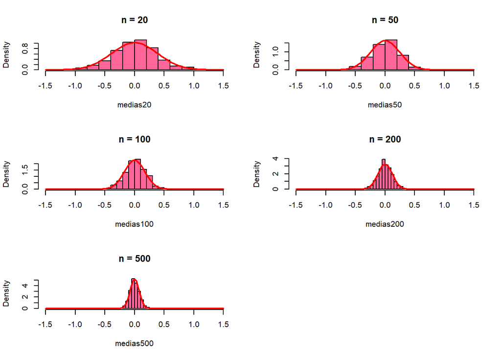

```r
# Para cada amostra gerada calcule a média amostral.

medias20<-numeric(1000)
# vetor para armazenar 1000 medias

i<-1

while (i <= 1000){

      medias20[i]<-mean(amostras20[i,])
      i<-i+1

}

#-------------------------------------------------------------------------------

medias50<-numeric(1000)
i<-1

while (i <= 1000){

      medias50[i]<-mean(amostras50[i,])
      i<-i+1

}

#-------------------------------------------------------------------------------

medias100<-numeric(1000)
i<-1

while (i <= 1000){

      medias100[i]<-mean(amostras100[i,])
      i<-i+1

}

#-------------------------------------------------------------------------------

medias200<-numeric(1000)
i<-1

while (i <= 1000){

      medias200[i]<-mean(amostras200[i,])
      i<-i+1

}

#-------------------------------------------------------------------------------

medias500<-numeric(1000)
i<-1

while (i <= 1000){

      medias500[i]<-mean(amostras500[i,])
      i<-i+1

}


# GRAFICOS ---------------------------------------------------------------------

par(mfrow = c(3,2), mar = c(5, 4, 4, 2) + 0.1)

hist(medias20, freq = FALSE, col = '#FF6699', main = 'n = 20', xlim= c(-1.5, 1.5))
curve(dnorm(x, mean=0, sd=sqrt((3)/20)), col = 'red', add = TRUE, lwd = 2)

hist(medias50, freq = FALSE, col = '#FF6699', main = 'n = 50', xlim= c(-1.5, 1.5))
curve(dnorm(x, mean=0, sd=sqrt((3)/50)), col = 'red', add = TRUE,lwd = 2)

hist(medias100, freq = FALSE, col = '#FF6699', main = 'n = 100', xlim= c(-1.5, 1.5))
curve(dnorm(x, mean=0, sd=sqrt((3)/100)), col = 'red', add = TRUE, lwd = 2)

hist(medias200, freq = FALSE, col = '#FF6699', main = 'n = 200', xlim= c(-1.5, 1.5))
curve(dnorm(x, mean=0, sd=sqrt((3)/200)), col = 'red', add = TRUE,lwd = 2)

hist(medias500, freq = FALSE, col = '#FF6699', main = 'n = 500', xlim= c(-1.5, 1.5))
curve(dnorm(x, mean=0, sd=sqrt((3)/500)), col = 'red', add = TRUE, lwd = 2)
```

#### Me parece justa a aproximacao das distribuicoes pela normal para todos os valores de n considerados. Media centrada na media populacional (=0) e variancia inversamente proporcional ao tamanho n da amostra (tcl).

### Bernoulli(0.1)

```r
# Considere que tem uma população com uma distribuição conhecida (descrita
# abaixo). Gere 1000 amostras de tamanho n (n=20, 50, 100, 200 e 500)
# provenientes desta população.

amostras20<-matrix(data = NA, nrow = 1000, ncol = 20 )
# cada linha armazena uma amostra de tam 20

i<-1

while (i <= 1000){

      amostras20[i,]<-rbern(20,0.1)
      i<- i+1

}

any(is.na(amostras20)) # verifica se matriz contem NA's
```

```
## [1] FALSE
```

```r
# ------------------------------------------------------------------------------

amostras50<-matrix(data = NA, nrow = 1000, ncol = 50 )
# cada linha armazena uma amostra de tam 20

i<-1

while (i <= 1000){

      amostras50[i,]<-rbern(50,0.1)
      i<- i+1

}

any(is.na(amostras50)) # verifica se matriz contem NA's
```

```
## [1] FALSE
```

```r
# ------------------------------------------------------------------------------

amostras100<-matrix(data = NA, nrow = 1000, ncol = 100 )
# cada linha armazena uma amostra de tam 20

i<-1

while (i <= 1000){

      amostras100[i,]<-rbern(100,0.1)
      i<- i+1

}

any(is.na(amostras100)) # verifica se matriz contem NA's
```

```
## [1] FALSE
```

```r
# ------------------------------------------------------------------------------

amostras200<-matrix(data = NA, nrow = 1000, ncol = 200 )
# cada linha armazena uma amostra de tam 20

i<-1

while (i <= 1000){

      amostras200[i,]<-rbern(200,0.1)
      i<- i+1

}

any(is.na(amostras200)) # verifica se matriz contem NA's
```

```
## [1] FALSE
```

```r
# ------------------------------------------------------------------------------

amostras500<-matrix(data = NA, nrow = 1000, ncol = 500 )
# cada linha armazena uma amostra de tam 20

i<-1

while (i <= 1000){

      amostras500[i,]<-rbern(500,0.1)
      i<- i+1

}

any(is.na(amostras500)) # verifica se matriz contem NA's
```

```
## [1] FALSE
```

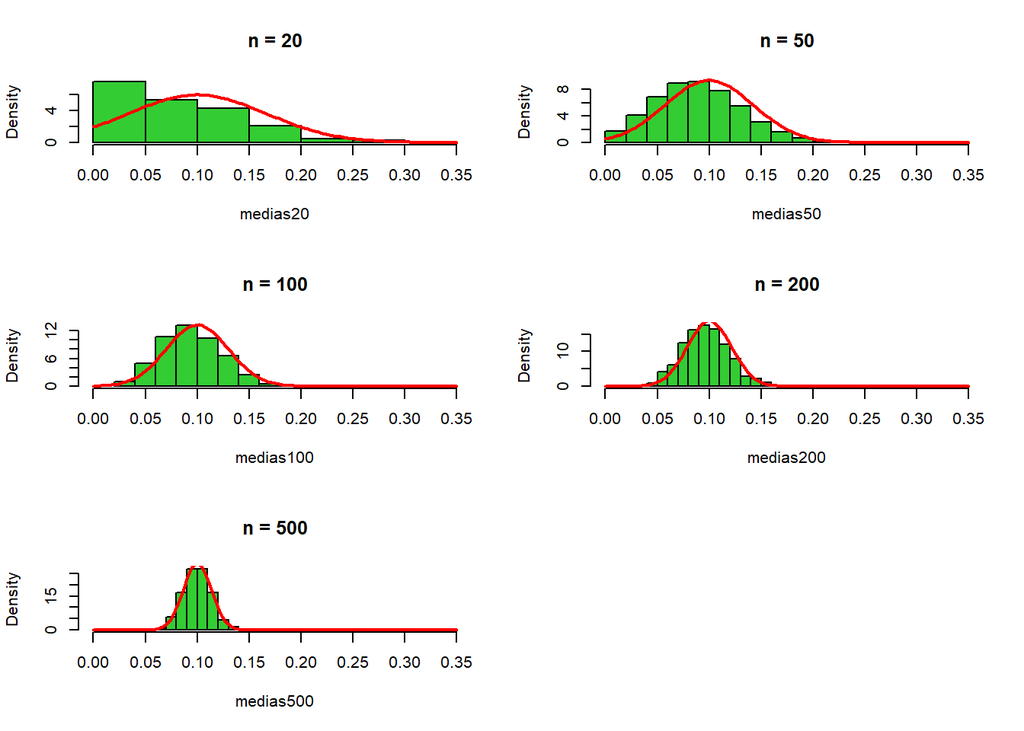

```r
# Para cada amostra gerada calcule a média amostral.

medias20<-numeric(1000)
# vetor para armazenar 1000 medias

i<-1

while (i <= 1000){

      medias20[i]<-mean(amostras20[i,])
      i<-i+1

}

#-------------------------------------------------------------------------------

medias50<-numeric(1000)
i<-1

while (i <= 1000){

      medias50[i]<-mean(amostras50[i,])
      i<-i+1

}

#-------------------------------------------------------------------------------

medias100<-numeric(1000)
i<-1

while (i <= 1000){

      medias100[i]<-mean(amostras100[i,])
      i<-i+1

}

#-------------------------------------------------------------------------------

medias200<-numeric(1000)
i<-1

while (i <= 1000){

      medias200[i]<-mean(amostras200[i,])
      i<-i+1

}

#-------------------------------------------------------------------------------

medias500<-numeric(1000)
i<-1

while (i <= 1000){

      medias500[i]<-mean(amostras500[i,])
      i<-i+1

}


# GRAFICOS ---------------------------------------------------------------------

par(mfrow = c(3,2), mar = c(5, 4, 4, 2) + 0.1)

hist(medias20, freq = FALSE, col = '#33CC33', main = 'n = 20', xlim = c(0,0.35))
curve(dnorm(x, mean=0.1, sd=sqrt((0.9*0.1)/20)), col = 'red', add = TRUE, lwd = 2)

hist(medias50, freq = FALSE, col = '#33CC33', main = 'n = 50', xlim = c(0,0.35))
curve(dnorm(x, mean=0.1, sd=sqrt((0.9*0.1)/50)), col = 'red', add = TRUE,lwd = 2)

hist(medias100, freq = FALSE, col = '#33CC33', main = 'n = 100', xlim = c(0,0.35))
curve(dnorm(x, mean=0.1, sd=sqrt((0.9*0.1)/100)), col = 'red', add = TRUE, lwd = 2)

hist(medias200, freq = FALSE, col = '#33CC33', main = 'n = 200', xlim = c(0,0.35))
curve(dnorm(x, mean=0.1, sd=sqrt((0.9*0.1)/200)), col = 'red', add = TRUE,lwd = 2)

hist(medias500, freq = FALSE, col = '#33CC33', main = 'n = 500', xlim = c(0,0.35))
curve(dnorm(x, mean=0.1, sd=sqrt((0.9*0.1)/500)), col = 'red', add = TRUE, lwd = 2)
```

#### As medias amostrais de Bernoulli(0.1) passam a apresentar relativa simetria apenas a partir de n = 50 (mas ainda nao podem ser aproximadas decentemente pela normal) e a ficarem centradas na media populacional apenas em n = 500. Isso revela a necessidade de se atribuir um valor maior a “n suficientemente grande” no caso dessa distribuicao (com esse parametro). Essa foi a distribuicao mais interessante de se trabalhar ate agora, pois foi possivel visualizar que para n = 20 a distribuicao nem se aproxima de uma normal ainda, o que pode causar erros grosseiros pelos mais desatentos. Variabilidade diminuindo conforme n cresce e conforme o esperado pelo tcl.

### Bernoulli(0.3)

```r
# Considere que tem uma população com uma distribuição conhecida (descrita
# abaixo). Gere 1000 amostras de tamanho n (n=20, 50, 100, 200 e 500)
# provenientes desta população.

amostras20<-matrix(data = NA, nrow = 1000, ncol = 20 )
# cada linha armazena uma amostra de tam 20

i<-1

while (i <= 1000){

      amostras20[i,]<-rbern(20,0.3)
      i<- i+1

}

any(is.na(amostras20)) # verifica se matriz contem NA's
```

```
## [1] FALSE
```

```r
# ------------------------------------------------------------------------------

amostras50<-matrix(data = NA, nrow = 1000, ncol = 50 )
# cada linha armazena uma amostra de tam 20

i<-1

while (i <= 1000){

      amostras50[i,]<-rbern(50,0.3)
      i<- i+1

}

any(is.na(amostras50)) # verifica se matriz contem NA's
```

```
## [1] FALSE
```

```r
# ------------------------------------------------------------------------------

amostras100<-matrix(data = NA, nrow = 1000, ncol = 100 )
# cada linha armazena uma amostra de tam 20

i<-1

while (i <= 1000){

      amostras100[i,]<-rbern(100,0.3)
      i<- i+1

}

any(is.na(amostras100)) # verifica se matriz contem NA's
```

```
## [1] FALSE
```

```r
# ------------------------------------------------------------------------------

amostras200<-matrix(data = NA, nrow = 1000, ncol = 200 )
# cada linha armazena uma amostra de tam 20

i<-1

while (i <= 1000){

      amostras200[i,]<-rbern(200,0.3)
      i<- i+1

}

any(is.na(amostras200)) # verifica se matriz contem NA's
```

```
## [1] FALSE
```

```r
# ------------------------------------------------------------------------------

amostras500<-matrix(data = NA, nrow = 1000, ncol = 500 )
# cada linha armazena uma amostra de tam 20

i<-1

while (i <= 1000){

      amostras500[i,]<-rbern(500,0.3)
      i<- i+1

}

any(is.na(amostras500)) # verifica se matriz contem NA's
```

```
## [1] FALSE
```

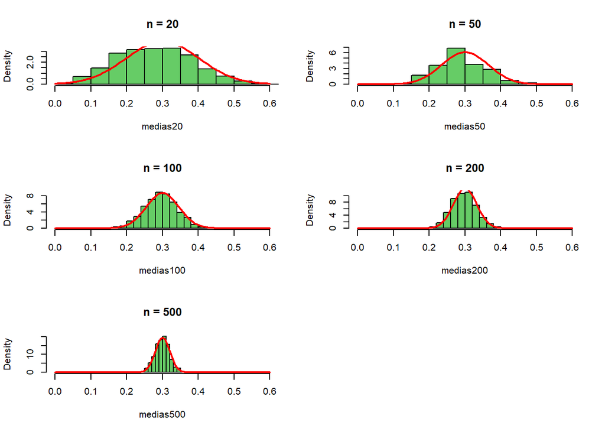

```r
# Para cada amostra gerada calcule a média amostral.

medias20<-numeric(1000)
# vetor para armazenar 1000 medias

i<-1

while (i <= 1000){

      medias20[i]<-mean(amostras20[i,])
      i<-i+1

}

#-------------------------------------------------------------------------------

medias50<-numeric(1000)
i<-1

while (i <= 1000){

      medias50[i]<-mean(amostras50[i,])
      i<-i+1

}

#-------------------------------------------------------------------------------

medias100<-numeric(1000)
i<-1

while (i <= 1000){

      medias100[i]<-mean(amostras100[i,])
      i<-i+1

}

#-------------------------------------------------------------------------------

medias200<-numeric(1000)
i<-1

while (i <= 1000){

      medias200[i]<-mean(amostras200[i,])
      i<-i+1

}

#-------------------------------------------------------------------------------

medias500<-numeric(1000)
i<-1

while (i <= 1000){

      medias500[i]<-mean(amostras500[i,])
      i<-i+1

}


# GRAFICOS ---------------------------------------------------------------------

par(mfrow = c(3,2), mar = c(5, 4, 4, 2) + 0.1)

hist(medias20, freq = FALSE, col = '#66CC66', main = 'n = 20', xlim = c(0,0.6))
curve(dnorm(x, mean=0.3, sd=sqrt((0.7*0.3)/20)), col = 'red', add = TRUE, lwd = 2)

hist(medias50, freq = FALSE, col = '#66CC66', main = 'n = 50', xlim = c(0,0.6))
curve(dnorm(x, mean=0.3, sd=sqrt((0.7*0.3)/50)), col = 'red', add = TRUE,lwd = 2)

hist(medias100, freq = FALSE, col = '#66CC66', main = 'n = 100', xlim = c(0,0.6))
curve(dnorm(x, mean=0.3, sd=sqrt((0.7*0.3)/100)), col = 'red', add = TRUE, lwd = 2)

hist(medias200, freq = FALSE, col = '#66CC66', main = 'n = 200', xlim = c(0,0.6))
curve(dnorm(x, mean=0.3, sd=sqrt((0.7*0.3)/200)), col = 'red', add = TRUE,lwd = 2)

hist(medias500, freq = FALSE, col = '#66CC66', main = 'n = 500', xlim = c(0,0.6))
curve(dnorm(x, mean=0.3, sd=sqrt((0.7*0.3)/500)), col = 'red', add = TRUE, lwd = 2)
```

#### Convergencia mais rapida em relacao a Bernoulli(0.1). Simetria e aproximacao pela normal boa partir de n = 100. Variabilidade inversamente proporcional ao tamanho amostral.

### Bernoulli(0.5)

```r
# Considere que tem uma população com uma distribuição conhecida (descrita
# abaixo). Gere 1000 amostras de tamanho n (n=20, 50, 100, 200 e 500)
# provenientes desta população.

amostras20<-matrix(data = NA, nrow = 1000, ncol = 20 )
# cada linha armazena uma amostra de tam 20

i<-1

while (i <= 1000){

      amostras20[i,]<-rbern(20,0.5)
      i<- i+1

}

any(is.na(amostras20)) # verifica se matriz contem NA's
```

```
## [1] FALSE
```

```r
# ------------------------------------------------------------------------------

amostras50<-matrix(data = NA, nrow = 1000, ncol = 50 )
# cada linha armazena uma amostra de tam 20

i<-1

while (i <= 1000){

      amostras50[i,]<-rbern(50,0.5)
      i<- i+1

}

any(is.na(amostras50)) # verifica se matriz contem NA's
```

```
## [1] FALSE
```

```r
# ------------------------------------------------------------------------------

amostras100<-matrix(data = NA, nrow = 1000, ncol = 100 )
# cada linha armazena uma amostra de tam 20

i<-1

while (i <= 1000){

      amostras100[i,]<-rbern(100,0.5)
      i<- i+1

}

any(is.na(amostras100)) # verifica se matriz contem NA's
```

```
## [1] FALSE
```

```r
# ------------------------------------------------------------------------------

amostras200<-matrix(data = NA, nrow = 1000, ncol = 200 )
# cada linha armazena uma amostra de tam 20

i<-1

while (i <= 1000){

      amostras200[i,]<-rbern(200,0.5)
      i<- i+1

}

any(is.na(amostras200)) # verifica se matriz contem NA's
```

```
## [1] FALSE
```

```r
# ------------------------------------------------------------------------------

amostras500<-matrix(data = NA, nrow = 1000, ncol = 500 )
# cada linha armazena uma amostra de tam 20

i<-1

while (i <= 1000){

      amostras500[i,]<-rbern(500,0.5)
      i<- i+1

}

any(is.na(amostras500)) # verifica se matriz contem NA's
```

```
## [1] FALSE
```

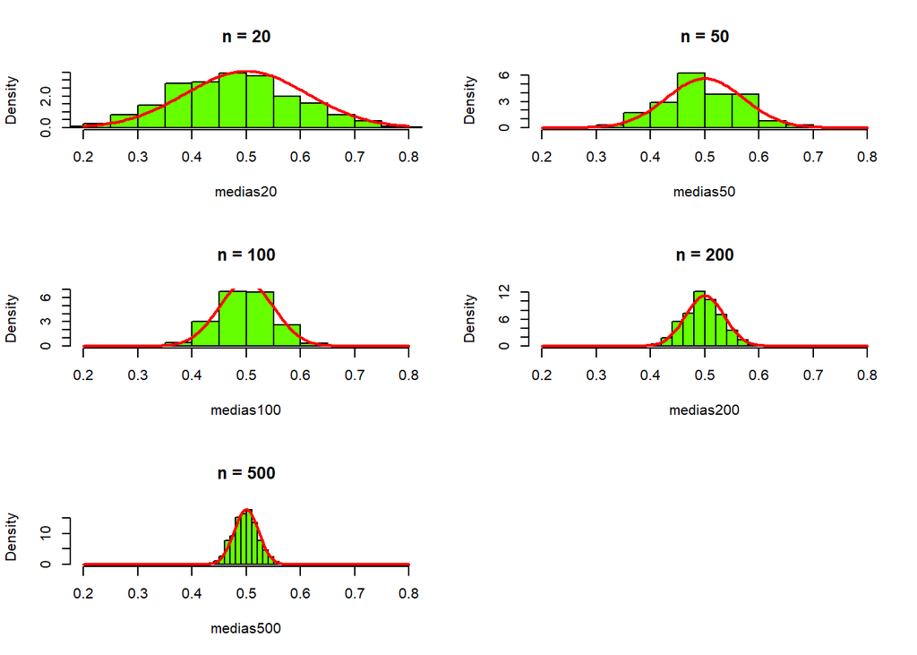

```r
# Para cada amostra gerada calcule a média amostral.

medias20<-numeric(1000)
# vetor para armazenar 1000 medias

i<-1

while (i <= 1000){

      medias20[i]<-mean(amostras20[i,])
      i<-i+1

}

#-------------------------------------------------------------------------------

medias50<-numeric(1000)
i<-1

while (i <= 1000){

      medias50[i]<-mean(amostras50[i,])
      i<-i+1

}

#-------------------------------------------------------------------------------

medias100<-numeric(1000)
i<-1

while (i <= 1000){

      medias100[i]<-mean(amostras100[i,])
      i<-i+1

}

#-------------------------------------------------------------------------------

medias200<-numeric(1000)
i<-1

while (i <= 1000){

      medias200[i]<-mean(amostras200[i,])
      i<-i+1

}

#-------------------------------------------------------------------------------

medias500<-numeric(1000)
i<-1

while (i <= 1000){

      medias500[i]<-mean(amostras500[i,])
      i<-i+1

}


# GRAFICOS ---------------------------------------------------------------------

par(mfrow = c(3,2), mar = c(5, 4, 4, 2) + 0.1)

hist(medias20, freq = FALSE, col = '#66FF00', main = 'n = 20', xlim = c(0.2,0.8))
curve(dnorm(x, mean=0.5, sd=sqrt((0.5*0.5)/20)), col = 'red', add = TRUE, lwd = 2)

hist(medias50, freq = FALSE, col = '#66FF00', main = 'n = 50', xlim = c(0.2,0.8))
curve(dnorm(x, mean=0.5, sd=sqrt((0.5*0.5)/50)), col = 'red', add = TRUE,lwd = 2)

hist(medias100, freq = FALSE, col = '#66FF00', main = 'n = 100', xlim = c(0.2,0.8))
curve(dnorm(x, mean=0.5, sd=sqrt((0.5*0.5)/100)), col = 'red', add = TRUE, lwd = 2)

hist(medias200, freq = FALSE, col = '#66FF00', main = 'n = 200', xlim = c(0.2,0.8))
curve(dnorm(x, mean=0.5, sd=sqrt((0.5*0.5)/200)), col = 'red', add = TRUE,lwd = 2)

hist(medias500, freq = FALSE, col = '#66FF00', main = 'n = 500', xlim = c(0.2,0.8))
curve(dnorm(x, mean=0.5, sd=sqrt((0.5*0.5)/500)), col = 'red', add = TRUE, lwd = 2)
```

#### Simetria a partir de n = 100. Me parece que, conforme o parametro da Bernoulli cresce em modulo, mais rapida fica a convergencia com a normal (mas nao posso afirmar ao certo). Valores concentrados em torno da media populacional e variabilidade inversamente proporcional a n.

### Bernoulli(0.8)

```r
# Considere que tem uma população com uma distribuição conhecida (descrita
# abaixo). Gere 1000 amostras de tamanho n (n=20, 50, 100, 200 e 500)
# provenientes desta população.

amostras20<-matrix(data = NA, nrow = 1000, ncol = 20 )
# cada linha armazena uma amostra de tam 20

i<-1

while (i <= 1000){

      amostras20[i,]<-rbern(20,0.8)
      i<- i+1

}

any(is.na(amostras20)) # verifica se matriz contem NA's
```

```
## [1] FALSE
```

```r
# ------------------------------------------------------------------------------

amostras50<-matrix(data = NA, nrow = 1000, ncol = 50 )
# cada linha armazena uma amostra de tam 20

i<-1

while (i <= 1000){

      amostras50[i,]<-rbern(50,0.8)
      i<- i+1

}

any(is.na(amostras50)) # verifica se matriz contem NA's
```

```
## [1] FALSE
```

```r
# ------------------------------------------------------------------------------

amostras100<-matrix(data = NA, nrow = 1000, ncol = 100 )
# cada linha armazena uma amostra de tam 20

i<-1

while (i <= 1000){

      amostras100[i,]<-rbern(100,0.8)
      i<- i+1

}

any(is.na(amostras100)) # verifica se matriz contem NA's
```

```
## [1] FALSE
```

```r
# ------------------------------------------------------------------------------

amostras200<-matrix(data = NA, nrow = 1000, ncol = 200 )
# cada linha armazena uma amostra de tam 20

i<-1

while (i <= 1000){

      amostras200[i,]<-rbern(200,0.8)
      i<- i+1

}

any(is.na(amostras200)) # verifica se matriz contem NA's
```

```
## [1] FALSE
```

```r
# ------------------------------------------------------------------------------

amostras500<-matrix(data = NA, nrow = 1000, ncol = 500 )
# cada linha armazena uma amostra de tam 20

i<-1

while (i <= 1000){

      amostras500[i,]<-rbern(500,0.8)
      i<- i+1

}

any(is.na(amostras500)) # verifica se matriz contem NA's
```

```
## [1] FALSE
```

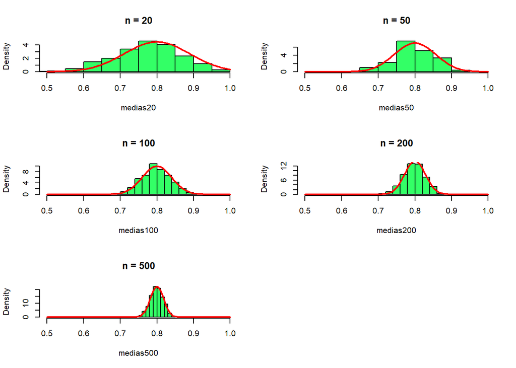

```r
# Para cada amostra gerada calcule a média amostral.

medias20<-numeric(1000)
# vetor para armazenar 1000 medias

i<-1

while (i <= 1000){

      medias20[i]<-mean(amostras20[i,])
      i<-i+1

}

#-------------------------------------------------------------------------------

medias50<-numeric(1000)
i<-1

while (i <= 1000){

      medias50[i]<-mean(amostras50[i,])
      i<-i+1

}

#-------------------------------------------------------------------------------

medias100<-numeric(1000)
i<-1

while (i <= 1000){

      medias100[i]<-mean(amostras100[i,])
      i<-i+1

}

#-------------------------------------------------------------------------------

medias200<-numeric(1000)
i<-1

while (i <= 1000){

      medias200[i]<-mean(amostras200[i,])
      i<-i+1

}

#-------------------------------------------------------------------------------

medias500<-numeric(1000)
i<-1

while (i <= 1000){

      medias500[i]<-mean(amostras500[i,])
      i<-i+1

}


# GRAFICOS ---------------------------------------------------------------------

par(mfrow = c(3,2), mar = c(5, 4, 4, 2) + 0.1)

hist(medias20, freq = FALSE, col = '#33FF66', main = 'n = 20', xlim = c(0.5,1))
curve(dnorm(x, mean=0.8, sd=sqrt((0.8*0.2)/20)), col = 'red', add = TRUE, lwd = 2)

hist(medias50, freq = FALSE, col = '#33FF66', main = 'n = 50', xlim = c(0.5,1))
curve(dnorm(x, mean=0.8, sd=sqrt((0.8*0.2)/50)), col = 'red', add = TRUE,lwd = 2)

hist(medias100, freq = FALSE, col = '#33FF66', main = 'n = 100', xlim = c(0.5,1))
curve(dnorm(x,mean=0.8, sd=sqrt((0.8*0.2)/100)), col = 'red', add = TRUE, lwd = 2)

hist(medias200, freq = FALSE, col = '#33FF66', main = 'n = 200', xlim = c(0.5,1))
curve(dnorm(x, mean=0.8, sd=sqrt((0.8*0.2)/200)), col = 'red', add = TRUE,lwd = 2)

hist(medias500, freq = FALSE, col = '#33FF66', main = 'n = 500', xlim = c(0.5,1))
curve(dnorm(x, mean=0.8, sd=sqrt((0.8*0.2)/500)), col = 'red', add = TRUE, lwd = 2)
```

#### Simetria muito boa a partir de n = 200. Aproximacao pela normal parece ser razoavel ja a partir de n = 20. Histogramas centrados na media populacional (=0.8) e variancia decrescendo a medida que n aumenta.

### Poisson(0.4)

```r
# Considere que tem uma população com uma distribuição conhecida (descrita
# abaixo). Gere 1000 amostras de tamanho n (n=20, 50, 100, 200 e 500)
# provenientes desta população.

amostras20<-matrix(data = NA, nrow = 1000, ncol = 20 )
# cada linha armazena uma amostra de tam 20

i<-1

while (i <= 1000){

      amostras20[i,]<-rpois(20,0.4)
      i<- i+1

}

any(is.na(amostras20)) # verifica se matriz contem NA's
```

```
## [1] FALSE
```

```r
# ------------------------------------------------------------------------------

amostras50<-matrix(data = NA, nrow = 1000, ncol = 50 )
# cada linha armazena uma amostra de tam 20

i<-1

while (i <= 1000){

      amostras50[i,]<-rpois(50,0.4)
      i<- i+1

}

any(is.na(amostras50)) # verifica se matriz contem NA's
```

```
## [1] FALSE
```

```r
# ------------------------------------------------------------------------------

amostras100<-matrix(data = NA, nrow = 1000, ncol = 100 )
# cada linha armazena uma amostra de tam 20

i<-1

while (i <= 1000){

      amostras100[i,]<-rpois(100,0.4)
      i<- i+1

}

any(is.na(amostras100)) # verifica se matriz contem NA's
```

```
## [1] FALSE
```

```r
# ------------------------------------------------------------------------------

amostras200<-matrix(data = NA, nrow = 1000, ncol = 200 )
# cada linha armazena uma amostra de tam 20

i<-1

while (i <= 1000){

      amostras200[i,]<-rpois(200,0.4)
      i<- i+1

}

any(is.na(amostras200)) # verifica se matriz contem NA's
```

```
## [1] FALSE
```

```r
# ------------------------------------------------------------------------------

amostras500<-matrix(data = NA, nrow = 1000, ncol = 500 )
# cada linha armazena uma amostra de tam 20

i<-1

while (i <= 1000){

      amostras500[i,]<-rpois(500,0.4)
      i<- i+1

}

any(is.na(amostras500)) # verifica se matriz contem NA's
```

```
## [1] FALSE
```

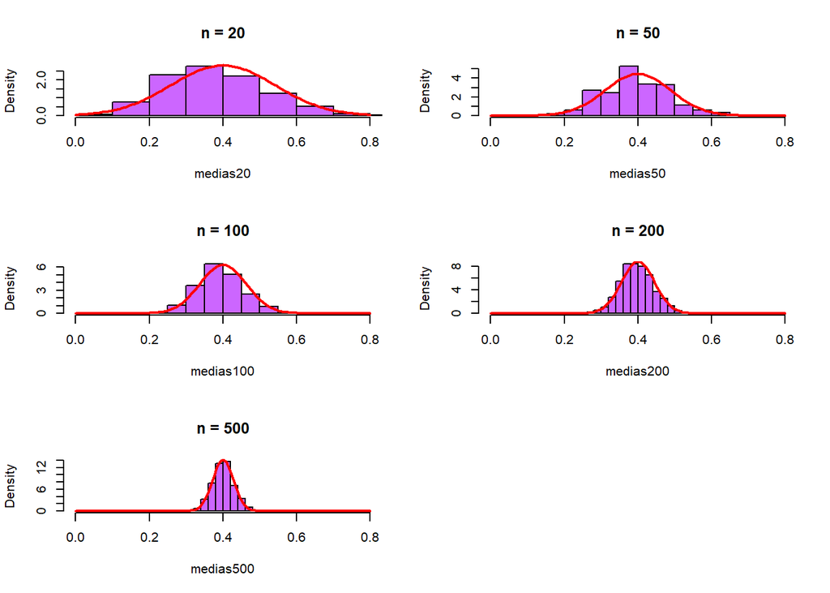

```r
# Para cada amostra gerada calcule a média amostral.

medias20<-numeric(1000)
# vetor para armazenar 1000 medias

i<-1

while (i <= 1000){

      medias20[i]<-mean(amostras20[i,])
      i<-i+1

}

#-------------------------------------------------------------------------------

medias50<-numeric(1000)
i<-1

while (i <= 1000){

      medias50[i]<-mean(amostras50[i,])
      i<-i+1

}

#-------------------------------------------------------------------------------

medias100<-numeric(1000)
i<-1

while (i <= 1000){

      medias100[i]<-mean(amostras100[i,])
      i<-i+1

}

#-------------------------------------------------------------------------------

medias200<-numeric(1000)
i<-1

while (i <= 1000){

      medias200[i]<-mean(amostras200[i,])
      i<-i+1

}

#-------------------------------------------------------------------------------

medias500<-numeric(1000)
i<-1

while (i <= 1000){

      medias500[i]<-mean(amostras500[i,])
      i<-i+1

}


# GRAFICOS ---------------------------------------------------------------------

par(mfrow = c(3,2), mar = c(5, 4, 4, 2) + 0.1)

hist(medias20, freq = FALSE, col = '#CC66FF', main = 'n = 20', xlim = c(0,0.8))
curve(dnorm(x, mean=0.4, sd=sqrt(0.4/20)), col = 'red', add = TRUE, lwd = 2)

hist(medias50, freq = FALSE, col = '#CC66FF', main = 'n = 50', xlim = c(0,0.8))
curve(dnorm(x, mean=0.4, sd=sqrt(0.4/50)), col = 'red', add = TRUE,lwd = 2)

hist(medias100, freq = FALSE, col = '#CC66FF', main = 'n = 100', xlim = c(0,0.8))
curve(dnorm(x,mean=0.4, sd=sqrt(0.4/100)), col = 'red', add = TRUE, lwd = 2)

hist(medias200, freq = FALSE, col = '#CC66FF', main = 'n = 200', xlim = c(0,0.8))
curve(dnorm(x, mean=0.4, sd=sqrt(0.4/200)), col = 'red', add = TRUE,lwd = 2)

hist(medias500, freq = FALSE, col = '#CC66FF', main = 'n = 500', xlim = c(0,0.8))
curve(dnorm(x, mean=0.4, sd=sqrt(0.4/500)), col = 'red', add = TRUE, lwd = 2)
```

#### Aproximacao e simetria boas a partir de n = 200. Histograma centrado em 0.4 (media da populacao). Variancia inversamente proporcional a n.